# Lab 8 Kriging

In this Lab we go through the process of carrying out spatio-temporal universal kriging using the semivariogram with the package `gstat`. We focus on the maximum temperature data in the NOAA data set (Tmax) in July 1993. In addition to the packages used in Chapter 2 for data wrangling, we need `RColorBrewer` to color some of the surfaces that will be produced.

```r
library("sp")
library("spacetime")
library("gstat")
library("RColorBrewer")
library("STRbook")
library("tidyverse")
```

For kriging of the maximum-temperature data set in July 1993, we need to fit a parametric function to the empirical semivariogram `vv` computed. The code is reproduced below for completeness.

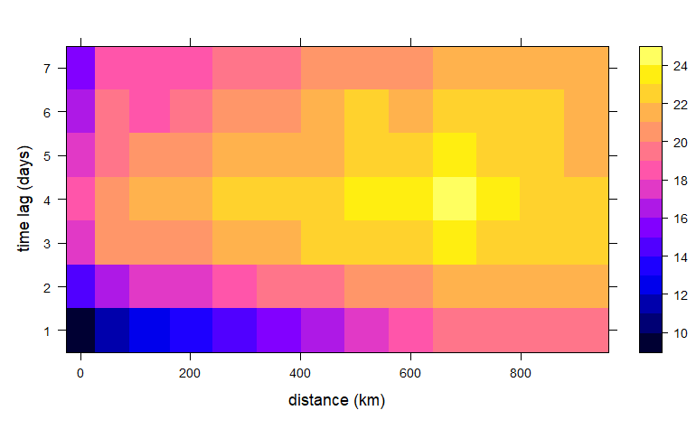

```r
data("STObj3", package = "STRbook")
STObj4 <- STObj3[, "1993-07-01::1993-07-31"]

vv <- variogram(object = z ~ 1 + lat, # fixed effect component
                data = STObj4, # July data
                width = 80, # spatial bin (80 km)
                cutoff = 1000, # consider pts < 1000 km apart
                tlags = 1:7) # 0 days to 6 days
plot(vv)
```

A number of covariance-function models are available with the package **gstat**; see the **gstat** vignette “spatio-temporal-kriging” for details by typing

```r
vignette("spatio-temporal-kriging")
```

A spatio-temporal semivariogram is constructed with **gstat** using the function `vgmST`. The argument `stModel = "separable"` is used to define a separable model, while the function `vgm` is used to construct the individual semivariograms (one for space and one for time). Several arguments can be passed to `vgm`. The first four, which we use below, correspond to the partial sill, the model type, the range, and the nugget, respectively. The argument sill that is supplied to `vgmST` defines the joint spatio-temporal sill. The numbers used in their definition are initial values supplied to the optimization routine used for fitting in the function `fit.StVariogram`, which fits `sepVgm` to `vv`. These initial values should be reasonable – for example, the length scale $φ$ can be set to a value that spans 10% of the spatial/temporal domain, and the variances/sills can be set such that they have similar orders of magnitude to the total variance of the measurements.

```r
sepVgm <- vgmST(stModel = "separable",
space = vgm(10, "Exp", 400, nugget = 0.1),
time = vgm(10, "Exp", 1, nugget = 0.1),
sill = 20)
sepVgm <- fit.StVariogram(vv, sepVgm)
```

Next, we use the fitted covariance models for prediction using kriging, in this case universal S-T kriging since we are treating the latitude coordinate as a covariate. First, we need to create a space-time prediction grid. For our spatial grid, we consider 20 spatial locations between 100◦W and 80◦W, and 20 spatial locations between 32◦N and 46◦N. In the code below, when converting to SpatialPoints, we ensure that the coordinate reference system (CRS) of the prediction grid is the same as that of the observations.

```r
spat_pred_grid <- expand.grid(lon = seq(-100, -80, length = 20),
                              lat = seq(32, 46, length = 20)) %>%
  SpatialPoints(proj4string = CRS(proj4string(STObj3)))
gridded(spat_pred_grid) <- TRUE
```

For our temporal grid, we consider six equally spaced days in July 1993.

```r
temp_pred_grid <- as.Date("1993-07-01") + seq(3, 28, length = 6)
```

We can then combine spat_pred_grid and temp_pred_grid to construct an STF object for our space-time prediction grid.

```r
DE_pred <- STF(sp = spat_pred_grid, # spatial part
               time = temp_pred_grid) # temporal part
```

Since there are missing observations in STObj4, we first need to cast STObj4 into either an STSDF or an STIDF, and remove the data recording missing observations. For simplicity here, we consider the STIDF (considering STSDF would be around twice as fast). Also, in order to show the capability of kriging to predict across time, we omitted data on 14 July 1993 from the data set.

```r
STObj5 <- as(STObj4[, -14], "STIDF") # convert to STIDF

STObj5 <- subset(STObj5, !is.na(STObj5$z)) # remove missing data
```

Now we can call krigeST using STObj5 as our data.

```r
pred_kriged <- krigeST(z ~ 1 + lat, # latitude trend
                       data = STObj5, # data set w/o 14 July
                       newdata = DE_pred, # prediction grid
                       modelList = sepVgm) # semivariogram
```

To plot the predictions, it is straightforward to use the function `stplot`. First, we define our color palette using the function brewer.pal and the function colorRampPalette (see help files for details on what these functions do).

```r
color_pal <- rev(colorRampPalette(brewer.pal(11, "Spectral"))(16))
```

Second, we call the stplot function with the object containing the results.

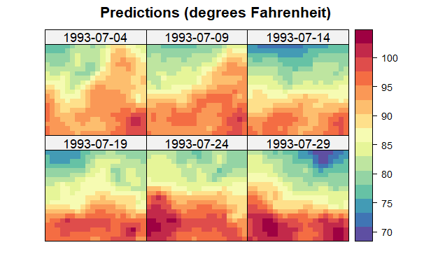

```r
stplot(pred_kriged,
main = "Predictions (degrees Fahrenheit)",
layout = c(3, 2),
col.regions = color_pal)
```

Spatio-temporal kriging as shown in this Lab is relatively quick and easy to implement for small data sets, but it starts to become prohibitive as data sets grow in size, unless some approximation is used. For example, the function krigeST allows one to use the argument nmax to determine the maximum number of observations to use when doing prediction. The predictor is no longer optimal, but it is close enough to the optimal predictor in many cases of practical interest.